# Text Analysis in R:

11/19/2019

## About me

[figure not shown]

- To pronounce Gonçalo **(gon salo)** just replace the *ç* with an *s*

## About me

**Education**

- 2008 BA in Applied Psychology, with a specialization in Clinical Psychology
- 2011 PgD in Social and Cultural Anthropology
- 2019 (December) MA in Clinical Psychology

**Recent work**

- Technical trainer

## Session structure

- Text mining overview
- Sentiment analysis approaches
- The *tidytext* package
- Lexicons
- Perform sentiment analysis
- Plot our results and analyze the data
- Final Considerations

## What is text mining?

- a set of approaches and methods at the intersection of different fields, such as computational linguistics, statistics, computer science
- textual data as input
- standard techniques include: text classification, text clustering, document summarization, stylometry, sentiment analysis

## What is text mining?

**Sources**

- Articles in blogs, newspapers, journals
- Books
- Social media
- Search engines
- Product reviews
- Surveys and questionnaires
- Patient and medical records, etc.

## What is text mining?

**Objective:**

- extract information from textual data to generate actionable insight
- support data driven decisions

**Challenges**

- unstructured
- dirty
- context

## Sentiment Analysis

“Sentiment analysis or opinion mining is the computational study of people’s opinions, appraisals, attitudes, and emotions toward entities, individuals, issues, events, topics and their attributes.” Liu & Zhang (2012)Liu, B. & Zhang, L. (2012). Mining Text Data. Springer: Boston, MA.

It allows us to:

- extract subjectivity
- extract polarity or direction
- measure intensity

## Two main approaches:

**Lexicon or dictionary approach**

- Calculates sentiment in a corpora through the semantic orientation of words or phrases in the documents.
- The dictionaries are usually user-generated.
- Words are annotated with scores or subjectivity values.
- They can either be general-purpose or specific-purpose.

Text classification approach

- Involves building classifiers from labeled instances of text or sentences, in a supervised classification task.
- It can be described as a statistical or machine learning approach.

## Two main techniques:

*Bag-of-Words*

- treats every word as a unique feature of the document
- word order and grammatical word type are not relevant in the analysis
- easy to perform

Semantic parsing

- based on word syntax: rules that define the components of a sentence
- uses Part-of-Speech (PoS) tagging to identify the words in a grammatical or useful context
- more sophisticated and complex

## Sentiment analysis steps

1. Problem definition: formulate the question
2. Select and collect the appropriate data
3. Organize the data into a corpora. Perform necessary data cleaning. Tokenize the document(s).
4. Apply the sentiment lexicon to the data
5. Visualize and analyze the data
6. Report on your findings and recommendations

## The tidytext package

- Julia Silge and David Robinson (2016)Silge, J. & Robinson, D. (2017). Text Mining with R. O’Reilly: Sebastapol, CA.
- based on tidy data principles
- treats text as data frames comprised of individual words
- easy to manipulate, summarize and visualize the characteristics of text

[figure not shown]

## The `unnest_tokens` function

Let’s look at a character vectorExcerpt from the John Lennon and Paul McCartney’s song Strawberry Fields Forever (1967):

```r
strawberry_ff <- c("Living is easy with eyes closed",
                   "Misunderstanding all you see",
                   "It's getting hard to be someone",
                   "But it all works out",
                   "It doesn't matter much to me")

strawberry_ff
```

```
## [1] "Living is easy with eyes closed" "Misunderstanding all you see"
## [3] "It's getting hard to be someone" "But it all works out"
## [5] "It doesn't matter much to me"
```

## The `unnest_tokens` function

Turn it into a tidy text dataset:

```r
library(dplyr)
(strawberry_DF <- tibble(line = 1:5, text = strawberry_ff))
```

```
## # A tibble: 5 x 2
##    line text
##   <int> <chr>
## 1     1 Living is easy with eyes closed
## 2     2 Misunderstanding all you see
## 3     3 It's getting hard to be someone
## 4     4 But it all works out
## 5     5 It doesn't matter much to me
```

## The `unnest_tokens` function

`tibble` is great because it does not convert strings to factors and it does not not use row names.

However we still need to tokenize our text for use with the `tidytext` `unnest_tokens()` function:

```r
library(tidytext)

strawberry_DF %>%
  unnest_tokens(word, text)
```

## The `unnest_tokens` function

```
## # A tibble: 27 x 2
##     line word
##    <int> <chr>
##  1     1 living
##  2     1 is
##  3     1 easy
##  4     1 with
##  5     1 eyes
##  6     1 closed
##  7     2 misunderstanding
##  8     2 all
##  9     2 you
## 10     2 see
## # … with 17 more rows
```

## The `unnest_tokens` function

The two main arguments in `unnest_tokens()` are columns names:

- first, we have the output column name which will be created as the text is unnested into a one-word token (`word`)
- second, we call the source column which contains the text of interest

In addition:

- The `line` column retains the line number each words belongs to
- Punctuation has been stripped
- Tokens have been converted to lowercase

## The `unnest_tokens` function

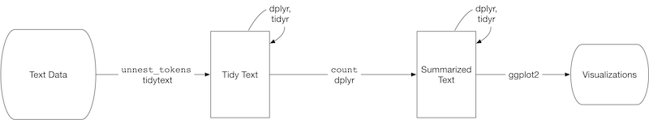

Formating the text into a `tidy data` structure allows us to manipulate, process, and visualize the data according to a set of tidy tools, such as `dplyr`, `tidyr`, and `gpplot2`.

## Tidying Jane Austen’s books

Silge (2017) compiled Jane Austen’s six published novels in the `janeaustenr` package(https://cran.r-project.org/web/packages/janeaustenr/index.html)

```r
library(janeaustenr)
library(stringr)
```

```r
original_books <- austen_books() %>%
  group_by(book) %>%
  mutate(linenumber = row_number(),
         #detect Roman numerals after "chapter" in the `text` column
         chapter = cumsum(str_detect(text, regex("^chapter [\\divxlc]",
                   ignore_case = TRUE)))) %>%
  #matches Roman numerals after "Chapter"
  ungroup()
```

## Tidying Jane Austen’s books

```r
original_books
```

```
## # A tibble: 73,422 x 4
##    text                  book                linenumber chapter
##    <chr>                 <fct>                    <int>   <int>
##  1 SENSE AND SENSIBILITY Sense & Sensibility          1       0
##  2 ""                    Sense & Sensibility          2       0
##  3 by Jane Austen        Sense & Sensibility          3       0
##  4 ""                    Sense & Sensibility          4       0
##  5 (1811)                Sense & Sensibility          5       0
##  6 ""                    Sense & Sensibility          6       0
##  7 ""                    Sense & Sensibility          7       0
##  8 ""                    Sense & Sensibility          8       0
##  9 ""                    Sense & Sensibility          9       0
## 10 CHAPTER 1             Sense & Sensibility         10       1
## # … with 73,412 more rows
```

## Convert to a one-token per row format

```r
(tidy_books <- original_books %>%
  unnest_tokens(word, text))
```

```
## # A tibble: 725,055 x 4
##    book                linenumber chapter word
##    <fct>                    <int>   <int> <chr>
##  1 Sense & Sensibility          1       0 sense
##  2 Sense & Sensibility          1       0 and
##  3 Sense & Sensibility          1       0 sensibility
##  4 Sense & Sensibility          3       0 by
##  5 Sense & Sensibility          3       0 jane
##  6 Sense & Sensibility          3       0 austen
##  7 Sense & Sensibility          5       0 1811
##  8 Sense & Sensibility         10       1 chapter
##  9 Sense & Sensibility         10       1 1
## 10 Sense & Sensibility         13       1 the
## # … with 725,045 more rows
```

## Removing stopwords

```r
tidytext::stop_words
```

```
## # A tibble: 1,149 x 2
##    word        lexicon
##    <chr>       <chr>
##  1 a           SMART
##  2 a's         SMART
##  3 able        SMART
##  4 about       SMART
##  5 above       SMART
##  6 according   SMART
##  7 accordingly SMART
##  8 across      SMART
##  9 actually    SMART
## 10 after       SMART
## # … with 1,139 more rows
```

## Removing stopwords

We can use `dplyr`’s `anti_join()` function to perform the removal:

```r
(tidy_books <- tidy_books %>%
  anti_join(stop_words))
```

```
## # A tibble: 217,609 x 4
##    book                linenumber chapter word
##    <fct>                    <int>   <int> <chr>
##  1 Sense & Sensibility          1       0 sense
##  2 Sense & Sensibility          1       0 sensibility
##  3 Sense & Sensibility          3       0 jane
##  4 Sense & Sensibility          3       0 austen
##  5 Sense & Sensibility          5       0 1811
##  6 Sense & Sensibility         10       1 chapter
##  7 Sense & Sensibility         10       1 1
##  8 Sense & Sensibility         13       1 family
##  9 Sense & Sensibility         13       1 dashwood
## 10 Sense & Sensibility         13       1 settled
## # … with 217,599 more rows
```

## Using `count()` to find most common words

```r
(tidy_books %>%
dplyr::count(word, sort = TRUE))
```

```
## # A tibble: 13,914 x 2
##    word       n
##    <chr>  <int>
##  1 miss    1855
##  2 time    1337
##  3 fanny    862
##  4 dear     822
##  5 lady     817
##  6 sir      806
##  7 day      797
##  8 emma     787
##  9 sister   727
## 10 house    699
## # … with 13,904 more rows
```

## Plot the most frequent words across the novels

```r
library(ggplot2)
top_words_austen <- tidy_books %>%
  count(word, sort = TRUE) %>%
  filter(n > 600) %>%
  mutate(word = reorder(word, n)) %>%
  ggplot(aes(word, n)) +
  geom_col() +
  xlab(NULL) +
  coord_flip() +
  theme_light() +
  labs(title = "Top Frequent Words in Jane Austen's novels")
```

## Plot the most frequent words across the novels

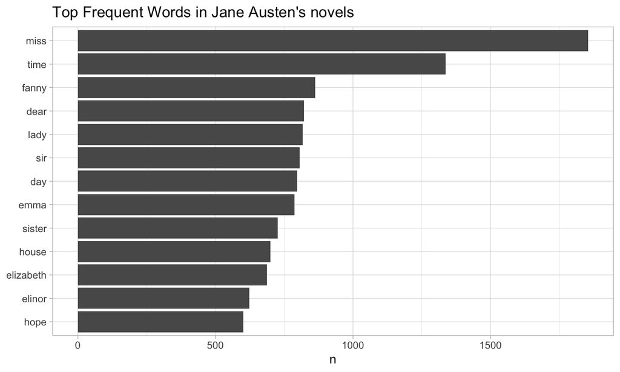

## Removing other words from text

```r
tidy_books_clean <- tidy_books %>%
  anti_join(tibble(word = c("miss", "lady", "sir", "dear")),
            by = "word") %>%
  count(word, sort = TRUE) %>%
  filter(n > 550) %>%
  mutate(word = reorder(word, n)) %>%
  ggplot(aes(word, n)) +
  geom_col() +
  xlab(NULL) +
  coord_flip() +
  theme_light() +
  labs(title = "Top Frequent Words in Jane Austen's novels")
```

## Removing other words from text

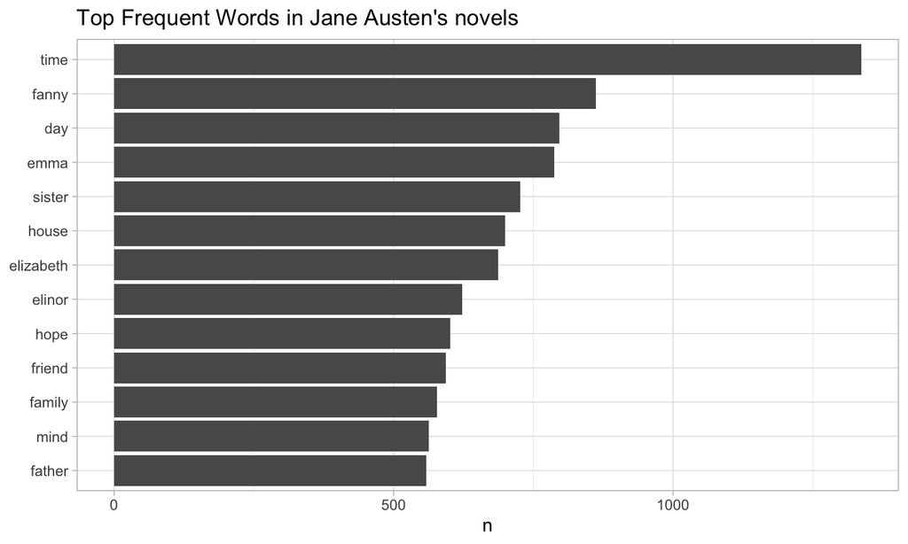

```r
tidy_books_clean
```

## Lexicons

There are four lexicons avaliable in the `tidytext` package

- Afinn, Bing, Loughran-MacDonald, and NRC

```r
get_sentiments(lexicon = c("afinn", "bing", "loughran", "nrc"))
```

- While they may share similar words, each has different word counts and associated values (subjectivity, polarity, and intensity)
- **Validation:** some were validated individually by the authors while some resorted to crowdsourcing, for instance, via Mechanical Turks.

## The Afinn lexicon

AFINN was developed by Finn Arup Nielsen. It includes 2477 terms and terms are rated between -5 to 5.

```r
get_sentiments("afinn") %>% count(value)
```

```
## # A tibble: 11 x 2
##    value     n
##    <dbl> <int>
##  1    -5    16
##  2    -4    43
##  3    -3   264
##  4    -2   966
##  5    -1   309
##  6     0     1
##  7     1   208
##  8     2   448
##  9     3   172
## 10     4    45
## 11     5     5
```

## The Bing lexicon

Bing was developed by Bing Liu and colleagues. It contains 6786 terms, 2005 are rated positive and 4781 negative.

```r
get_sentiments("bing") %>%
  count(sentiment)
```

```
## # A tibble: 2 x 2
##   sentiment     n
##   <chr>     <int>
## 1 negative   4781
## 2 positive   2005
```

## The Loughran-McDonald lexicon

Developed by Tim Loughran and Bill McDonald. The lexicon was constructed for use in finance and law. It contains 4150 terms and identifies four emotions and sentiment (positive and negative).

```r
get_sentiments("loughran") %>%
  count(sentiment)
```

```
## # A tibble: 6 x 2
##   sentiment        n
##   <chr>        <int>
## 1 constraining   184
## 2 litigious      904
## 3 negative      2355
## 4 positive       354
## 5 superfluous     56
## 6 uncertainty    297
```

## The NRC lexicon

The NRC lexicon includes ratings for 13901 terms and rates terms on sentiment (positive and negative) and on eight emotions, some with overlap.

```r
get_sentiments("nrc") %>% count(sentiment)
```

```
## # A tibble: 10 x 2
##    sentiment        n
##    <chr>        <int>
##  1 anger         1247
##  2 anticipation   839
##  3 disgust       1058
##  4 fear          1476
##  5 joy            689
##  6 negative      3324
##  7 positive      2312
##  8 sadness       1191
##  9 surprise       534
## 10 trust         1231
```

## `dplyr`’s `inner_join()`

`inner_join()` allows us to merge the sentiment dictonaries to our dataset, in effect being the function that performs the lexicon-based sentiment analysis approach.

An inner join matches pairs of observations whenever their keys are equal.Wickham, H. & Grolemund, G. (2017). R for Data Science. Import, Tidy, Transform, Visualize, and Model Data. O’Reilly: Sebastopol, CA.

## `dplyr`’s `inner_join()`

Save the lexicon to a data frame:

```r
(nrc <- get_sentiments("nrc"))
```

```
## # A tibble: 13,901 x 2
##    word        sentiment
##    <chr>       <chr>
##  1 abacus      trust
##  2 abandon     fear
##  3 abandon     negative
##  4 abandon     sadness
##  5 abandoned   anger
##  6 abandoned   fear
##  7 abandoned   negative
##  8 abandoned   sadness
##  9 abandonment anger
## 10 abandonment fear
## # … with 13,891 more rows
```

## `dplyr`’s `inner_join()`

Since we already tokenized Jane Austen’s books with the `unnest_tokens()`, performed the stopwords removal via `anti_join()`, we can now perform sentiment analysis by merging the `nrc` lexicon with the data.

```r
jane_austen_nrc <- inner_join(x = tidy_books,
                              y = nrc,
                              by = "word")
```

or:

```r
jane_austen_nrc <- tidy_books %>%
  inner_join(nrc)
```

## Jane Austen & `NRC`

```
## # A tibble: 159,272 x 5
##    book                linenumber chapter word        sentiment
##    <fct>                    <int>   <int> <chr>       <chr>
##  1 Sense & Sensibility          1       0 sense       positive
##  2 Sense & Sensibility          1       0 sensibility positive
##  3 Sense & Sensibility         16       1 respectable positive
##  4 Sense & Sensibility         16       1 respectable trust
##  5 Sense & Sensibility         17       1 late        negative
##  6 Sense & Sensibility         17       1 late        sadness
##  7 Sense & Sensibility         18       1 advanced    positive
##  8 Sense & Sensibility         19       1 constant    positive
##  9 Sense & Sensibility         19       1 constant    trust
## 10 Sense & Sensibility         19       1 companion   joy
## # … with 159,262 more rows
```

## Filtering for a particular emotion:

Use `dplyr`’s `filter()` function:

```r
jane_austen_nrc %>%
  filter(sentiment == "joy")
```

```
## # A tibble: 16,666 x 5
##    book                linenumber chapter word         sentiment
##    <fct>                    <int>   <int> <chr>        <chr>
##  1 Sense & Sensibility         19       1 companion    joy
##  2 Sense & Sensibility         28       1 goodness     joy
##  3 Sense & Sensibility         29       1 comfort      joy
##  4 Sense & Sensibility         29       1 cheerfulness joy
##  5 Sense & Sensibility         32       1 marriage     joy
##  6 Sense & Sensibility         34       1 fortune      joy
##  7 Sense & Sensibility         34       1 mother       joy
##  8 Sense & Sensibility         36       1 marriage     joy
##  9 Sense & Sensibility         37       1 wealth       joy
## 10 Sense & Sensibility         38       1 fortune      joy
## # … with 16,656 more rows
```

## Filtering for a sentiment in a particular book:

Filter both the sentiment and the particular book:

```r
jane_austen_nrc %>%
  filter(sentiment == "positive", book == "Emma")
```

```
## # A tibble: 8,454 x 5
##    book  linenumber chapter word      sentiment
##    <fct>      <int>   <int> <chr>     <chr>
##  1 Emma          15       1 clever    positive
##  2 Emma          16       1 happy     positive
##  3 Emma          16       1 blessings positive
##  4 Emma          17       1 existence positive
##  5 Emma          21       1 marriage  positive
##  6 Emma          22       1 mother    positive
##  7 Emma          24       1 excellent positive
##  8 Emma          25       1 mother    positive
##  9 Emma          25       1 affection positive
## 10 Emma          28       1 friend    positive
## # … with 8,444 more rows
```

## Filtering, grouping, and counting

```r
jane_austen_nrc %>% filter(sentiment == c("positive", "negative")) %>%
  group_by(book, sentiment) %>% count()
```

```
## # A tibble: 12 x 3
## # Groups:   book, sentiment [12]
##    book                sentiment     n
##    <fct>               <chr>     <int>
##  1 Sense & Sensibility negative   1953
##  2 Sense & Sensibility positive   3353
##  3 Pride & Prejudice   negative   1769
##  4 Pride & Prejudice   positive   3348
##  5 Mansfield Park      negative   2334
##  6 Mansfield Park      positive   4150
##  7 Emma                negative   2168
##  8 Emma                positive   4278
##  9 Northanger Abbey    negative   1224
## 10 Northanger Abbey    positive   2051
## 11 Persuasion          negative   1082
## 12 Persuasion          positive   2382
```

## Visualizing the `NRC` sentiment analysis

```r
library(tidyr)
```

```r
jane_austen_nrc %>%
  filter(sentiment == c("positive", "negative")) %>%
  group_by(book, sentiment) %>%
  count(book, index = linenumber %/% 80, sentiment) %>%
  spread(sentiment, n, fill = 0) %>%
  mutate(sentiment = positive - negative) %>%
  ggplot(aes(index,
             sentiment,
             fill = book)) +
  geom_col(show.legend = FALSE) +
  facet_wrap(~ book, ncol = 2, scales = "free_x") +
  labs(title = "Sentiment Analysis of Jane Austen's novels")
```

## Visualizing the `NRC` sentiment analysis

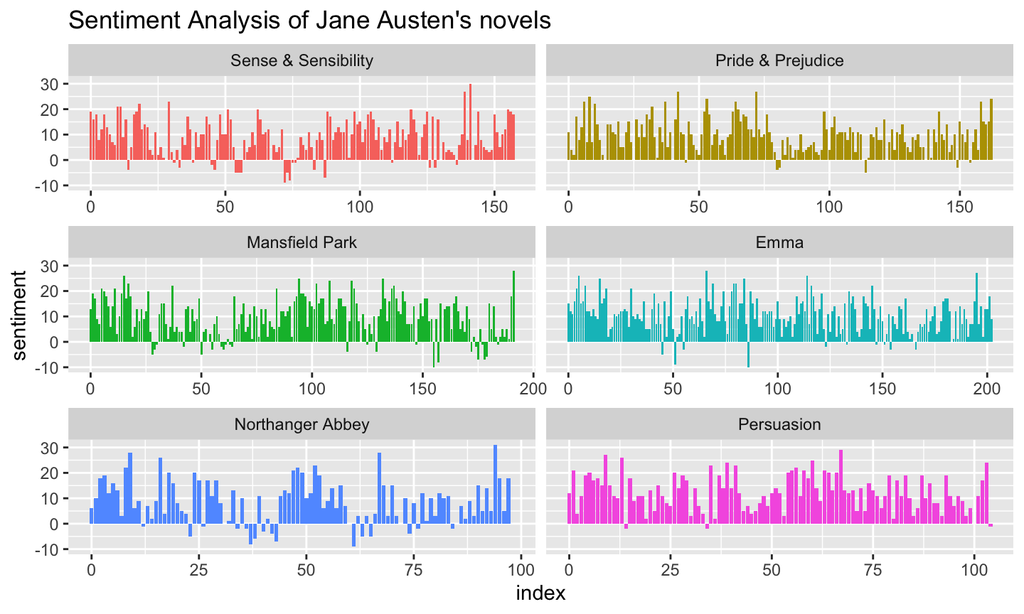

## Which are the most positive and negative words

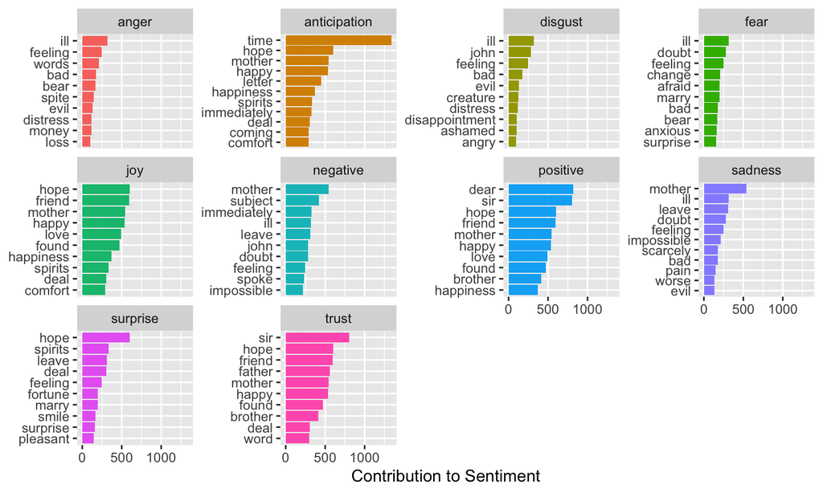

## Comparison Cloud with the Bing lexicon

```r
library(reshape2)
library(wordcloud)
```

```r
tidy_books %>%
  inner_join(get_sentiments("bing"), by = "word") %>%
  count(word, sentiment, sort = TRUE) %>%
  acast(word ~ sentiment, value.var = "n", fill = 0) %>%
  comparison.cloud(colors = c("gray2", "gray80"),
                   max.words = 100)
```

## Comparison Cloud with the Bing lexicon

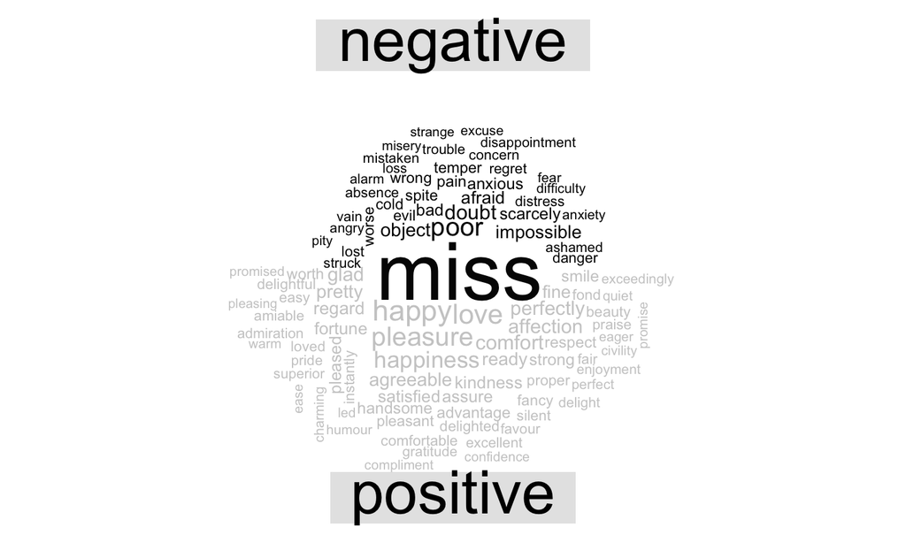

## Wordclouds with the Bing lexicon

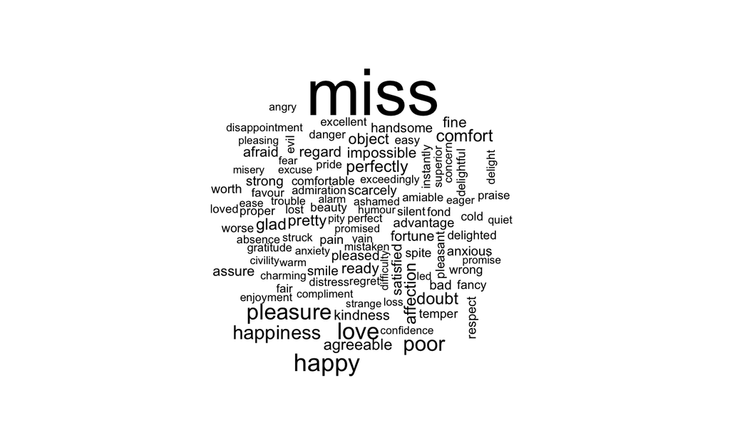

```r
tidy_books %>%
  inner_join(get_sentiments("bing"), by = "word") %>%
  count(word) %>%
  with(wordcloud(word, n, max.words = 100))
```

## Sentiment Analysis applied to customer reviews

Goal: Understand how customers feel about their roomba product purchase.

```r
library(readr)
(roomba_Reviews <- read_csv("Roomba Reviews.csv") %>%
  select(Product, Stars, Review))
```

```
## # A tibble: 1,833 x 3
##    Product             Stars Review
##    <chr>               <dbl> <chr>
##  1 iRobot Roomba 650 …     5 You would not believe how well this works
##  2 iRobot Roomba 650 …     4 You just walk away and it does the rest
##  3 iRobot Roomba 650 …     5 You have to Roomba proof your house but once …
##  4 iRobot Roomba 650 …     3 Yes, it's a fascinating, albeit expensive, bi…
##  5 iRobot Roomba 650 …     5 Years ago I bought one of the original Roomba…
##  6 iRobot Roomba 650 …     5 "Wow.Wow.  I never knew my floors were so dir…
##  7 iRobot Roomba 650 …     1 Wow.. I don't know what to say. This thing wo…
##  8 iRobot Roomba 650 …     5 Wow, wow, WOW!  I wanted to get one of these …
##  9 iRobot Roomba 650 …     5 Wow, the Roomba is the best christmas gift I'…
## 10 iRobot Roomba 650 …     5 Wow, it changes your life. First of all, afte…
## # … with 1,823 more rows
```

## Tidying it up!

```r
(roomba_tidy <- roomba_Reviews %>%
  unnest_tokens(word, Review) %>%
  anti_join(stop_words) %>%
  filter(!word== c("roomba"))) #remove common word
```

```
## # A tibble: 76,581 x 3
##    Product                    Stars word
##    <chr>                      <dbl> <chr>
##  1 iRobot Roomba 650 for Pets     4 walk
##  2 iRobot Roomba 650 for Pets     4 rest
##  3 iRobot Roomba 650 for Pets     5 proof
##  4 iRobot Roomba 650 for Pets     5 house
##  5 iRobot Roomba 650 for Pets     5 awesome
##  6 iRobot Roomba 650 for Pets     5 pet
##  7 iRobot Roomba 650 for Pets     5 cleans
##  8 iRobot Roomba 650 for Pets     3 fascinating
##  9 iRobot Roomba 650 for Pets     3 albeit
## 10 iRobot Roomba 650 for Pets     3 expensive
## # … with 76,571 more rows
```

## Sentiment Analysis using the Bing lexicon

```r
(roomba_bing <- roomba_tidy %>%
 inner_join(get_sentiments("bing")))
```

```
## # A tibble: 12,915 x 4
##    Product                    Stars word        sentiment
##    <chr>                      <dbl> <chr>       <chr>
##  1 iRobot Roomba 650 for Pets     5 awesome     positive
##  2 iRobot Roomba 650 for Pets     3 fascinating positive
##  3 iRobot Roomba 650 for Pets     3 expensive   negative
##  4 iRobot Roomba 650 for Pets     3 pain        negative
##  5 iRobot Roomba 650 for Pets     3 clean       positive
##  6 iRobot Roomba 650 for Pets     3 clog        negative
##  7 iRobot Roomba 650 for Pets     3 faster      positive
##  8 iRobot Roomba 650 for Pets     3 clean       positive
##  9 iRobot Roomba 650 for Pets     3 patience    positive
## 10 iRobot Roomba 650 for Pets     5 slow        negative
## # … with 12,905 more rows
```

## Sentiment across the reviews per product

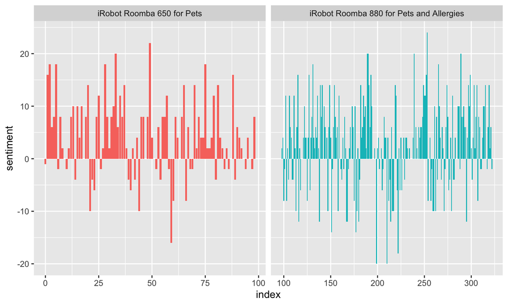

## Most frequently used words per product

For the iRobot Roomba 650 for Pets:

```r
roomba_bing %>%
  filter(Product == "iRobot Roomba 650 for Pets") %>%
  count(word, sort = TRUE) %>%
  filter(n > 50) %>%
  mutate(word = reorder(word, n)) %>%
  ggplot(aes(word, n)) +
  geom_col() +
  xlab(NULL) +
  coord_flip() +
  labs(title = "Top Words for iRobot Roomba 650 for Pets")
```

## iRobot Roomba 650 for Pets:

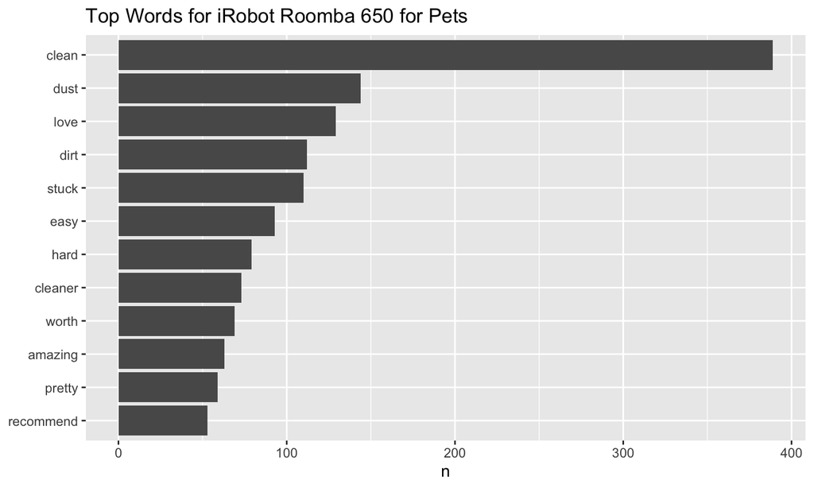

## iRobot Roomba 880 for Pets and Allergies:

```r
roomba_bing %>%
  filter(Product == "iRobot Roomba 880 for Pets and Allergies") %>%
  count(word, sort = TRUE) %>%
  filter(n > 200) %>%
  mutate(word = reorder(word, n)) %>%
  ggplot(aes(word, n)) +
  geom_col() +
  xlab(NULL) +
  coord_flip() +
  labs(title = "Top Words for iRobot Roomba 880 for Pets and Allergies")
```

## iRobot Roomba 880 for Pets and Allergies:

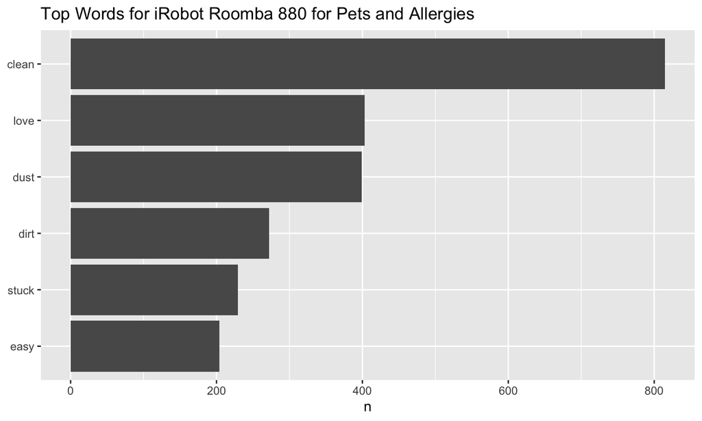

## Final Considerations

## References:

Liu, B. & Zhang, L. (2012). Mining Text Data. Springer: Boston, MA.

Silge, J. & Robinson, D. (2017). Text Mining with R. O’Reilly: Sebastapol, CA.

Wickham, H. & Grolemund, G. (2017). R for Data Science. Import, Tidy, Transform, Visualize, and Model Data. O’Reilly: Sebastopol, CA.